# Mann-Whitney-Wilcoxon Test

Aprendemos como a média amostral e o DP são suscetíveis a valores discrepantes. O teste t é baseado nessas medidas e também é suscetível. O teste de classificação de Wilcoxon (equivalente ao teste de Mann-Whitney) fornece uma alternativa. No código abaixo, realizamos um teste t nos dados para os quais o nulo é verdadeiro. No entanto, alteramos uma observação de soma por engano em cada amostra e os valores inseridos incorretamente são diferentes. Aqui vemos que o teste t resulta em um valor p pequeno, enquanto o teste de Wilcoxon não:

```r
set.seed(779) ##779 escolhido aleatoriamente
N=25
x<- rnorm(N,0,1)
y<- rnorm(N,0,1)
```

Crie valores discrepantes:

```r
x[1] <- 5
x[2] <- 7
cat("t-test pval:",t.test(x,y)$p.value)
```

```
t-test pval: 0.04439948
```

```r
cat("Wilcox test pval:",wilcox.test(x,y)$p.value)
```

```
Wilcox test pval: 0.1310212
```

A ideia básica é 1) combinar todos os dados, 2) transformar os valores em classificações, 3) separá-los novamente em seus grupos e 4) calcular a soma ou classificação média e realizar um teste.

```r
library(rafalib)
mypar(1,2)

stripchart(list(x,y),vertical=TRUE,ylim=c(-7,7),ylab="Observations",pch=21,bg=1)
abline(h=0)
```

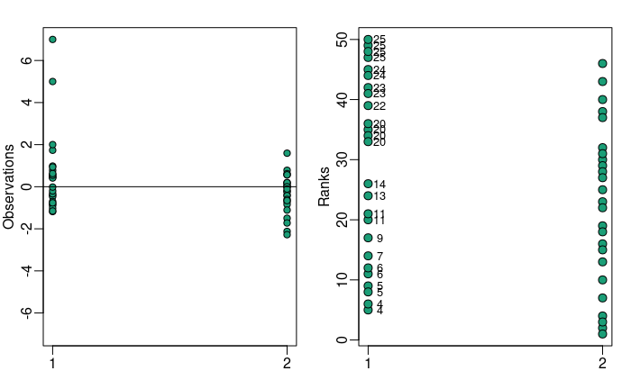

```r
xrank<-rank(c(x,y))[seq(along=x)]
yrank<-rank(c(x,y))[-seq(along=y)]

stripchart(list(xrank,yrank),vertical=TRUE,ylab="Ranks",pch=21,bg=1,cex=1.25)

ws <- sapply(x,function(z) rank(c(z,y))[1]-1)
text( rep(1.05,length(ws)), xrank, ws, cex=0.8)
```

Dados de duas populações com dois outliers. O gráfico da esquerda mostra os dados originais e o gráfico da direita mostra suas classificações. Os números são os valores w

```r
W <-sum(ws)
```

Wé a soma das classificações do primeiro grupo em relação ao segundo grupo. Podemos calcular um valor p exato paraC baseado em combinatória. Também podemos usar o CLT, pois a teoria estatística nos diz que este Wé aproximado pela distribuição normal. Podemos construir uma pontuação z da seguinte forma:

```r
n1<-length(x);n2<-length(y)
Z <- (mean(ws)-n2/2)/ sqrt(n2*(n1+n2+1)/12/n1)
print(Z)
```

```
[1] 1.523124
```

Aqui o Znão é grande o suficiente para nos dar um valor p inferior a 0,05. Estes fazem parte dos cálculos realizados pela função wilcox.testR.